# ASE - Practice 1

Siria Angino and Giuseppe Brandi

29 February 2016

### Installing `devtools`

`devtools` is a `R` package that allows interacting with package that are under development and are not part of `cran`. If you are on Windows, before installing `devtools` you need to install `Rtools`. `Rtools` is a program that installs a set of utilities that are needed by `R` when using in conjunction with `devtools`.

To install `Rtools`, point your browser to http://cran.r-project.org/bin/windows/Rtools/ and install the version that is compatible with your version of `R`. For instance, if you have installed `R 3.2.x` and later versions you need to install [Rtools 3.3](https://cran.r-project.org/bin/windows/Rtools/Rtools33.exe). While this is the most likely scenario check `R` version before installing.

Once installation of `Rtools` succeeded, you can turn to installation of `devtools`. This is done by

```r
install.packages("devtools")
```

If everything worked fine, you should be able to load your package

```r
library(devtools)
```

This step are meant to be executed only once. You do not need to install `Rtools` and `devtools` every time you start `R`.

### Updating installed packages

The stock installation of `R` has few packaged installed. These packages are required by `R` to work properly. However, these packages are updated frequently to fix bugs and improve they capabilities. This is also true for other packages that you may have installed on your computer.

To update all packages that are installed on your computer

```r
update.packages(ask = FALSE)
```

This command will download and install new versions of the packages installed. The option `ask = FALSE` prevents `R` to ask the user consent for the installation of each package. If for example, you do not want to install a specific package you should pass `ask = TRUE` to `update.packages` (or, since it is the default option, not pass anything at all) and say `N` to the package you do not want to be updated.

### Installing `ase`

The `ase` package is installed by issuing the following commands

```r
update.packages(ask = FALSE)
library(devtools)
# you do not need the previous command if you already loaded
# the library in the same session and already unpdate the installed packages
install_github("gragusa/ase")
```

You should now be able to load the `ase` library

```r
library(ase)
```

### Loading dataset from the `ase` package

The `ase` package comes with almost all dataset that we will use during the course. They way dataset are loaded into `R` is by using the `data` function. For instance, to load the `ceo` dataset, you execute:

```r
data(ceo)
```

Now `ceo` is a `data.frame` that contains the data about the CEO salary that you have seen in class.

### Exploring data

```r
head(ceo)
```

```
##   salary pcsalary     sales       roe      pcroe ros indus finance
## 1   1001       32  9958.000 10.900010 -30.600020  13     1       0
## 2   1122        9  6125.905 23.500000 -16.300010  14     1       0
## 3    578       -9 16246.000  5.900005 -25.700020 -21     1       0
## 4   1368        7 21783.220 13.800010  -3.000000  56     1       0
## 5   1145        5  6021.405 20.000000   1.000000  55     1       0
## 6   1078       10  2266.701 16.400010  -5.900005  62     1       0
##   consprod utility
## 1        0       0
## 2        0       0
## 3        0       0
## 4        0       0
## 5        0       0
## 6        0       0
```

The `head` function is useful as it displays the first parts of a vector, matrix, table, data frame or function. `head` can also be invoked using the argument `n` which specifies the number of rows to display

```r
head(ceo, n = 2)
```

```
##   salary pcsalary    sales      roe     pcroe ros indus finance consprod
## 1   1001       32 9958.000 10.90001 -30.60002  13     1       0        0
## 2   1122        9 6125.905 23.50000 -16.30001  14     1       0        0
##   utility
## 1       0
## 2       0
```

A similar function is `tail`, which displays the last part of an object.

The variables in the `data.frame` can be queried by using `names`. For instance

```r
names(ceo)
```

```
##  [1] "salary"   "pcsalary" "sales"    "roe"      "pcroe"    "ros"
##  [7] "indus"    "finance"  "consprod" "utility"
```

shows the variables in the `ceo` dataset.

The following commands should be self-explanatory.

`dim` returns the number of rows (i.e., the number of observations) and the number of column (i.e., the number of variables)

```r
dim(ceo)
```

```
## [1] 208  10
```

The `summary` function return a summary of the variables in the dataset. Specifically, it returns the median, mean, quartiles, mean, and max of each variables in the `data.frame`.

```r
summary(ceo)
```

```
##      salary         pcsalary          sales              roe
##  Min.   :  223   Min.   :-61.00   Min.   :  175.2   Min.   : 0.5
##  1st Qu.:  735   1st Qu.: -1.00   1st Qu.: 2200.3   1st Qu.:12.4
##  Median : 1032   Median :  9.00   Median : 3693.3   Median :15.5
##  Mean   : 1282   Mean   : 13.25   Mean   : 6824.4   Mean   :17.2
##  3rd Qu.: 1408   3rd Qu.: 19.25   3rd Qu.: 7017.2   3rd Qu.:20.0
##  Max.   :14822   Max.   :212.00   Max.   :97649.9   Max.   :56.3
##      pcroe             ros             indus           finance
##  Min.   :-98.90   Min.   :-58.00   Min.   :0.0000   Min.   :0.0000
##  1st Qu.:-21.48   1st Qu.: 20.75   1st Qu.:0.0000   1st Qu.:0.0000
##  Median : -3.15   Median : 52.00   Median :0.0000   Median :0.0000
##  Mean   : 10.34   Mean   : 61.18   Mean   :0.3173   Mean   :0.2212
##  3rd Qu.: 19.05   3rd Qu.: 81.00   3rd Qu.:1.0000   3rd Qu.:0.0000
##  Max.   :977.00   Max.   :418.00   Max.   :1.0000   Max.   :1.0000
##     consprod         utility
##  Min.   :0.0000   Min.   :0.0000
##  1st Qu.:0.0000   1st Qu.:0.0000
##  Median :0.0000   Median :0.0000
##  Mean   :0.2885   Mean   :0.1731
##  3rd Qu.:1.0000   3rd Qu.:0.0000
##  Max.   :1.0000   Max.   :1.0000
```

```r
median(ceo$salary)
```

```
## [1] 1032.5
```

```r
median(ceo[['salary']])
```

```
## [1] 1032.5
```

```r
median(ceo['salary']) ## Try this yourself --- it won't work
```

You can also use the `attach` function to directly access the variable in the dataset.

```r
attach(ceo)
mean(salary)
```

```
## [1] 1282.014
```

```r
detach(ceo)
```

In this case, `mean` will find `salary` since `ceo` has been attached (to the search path). `detach` instead remove `ceo` from the search path. Using `attach`/`detach` is however dangerous should never be used (unless there is a reason for it). A better way to deal with accessing variables in a `data.frame` is to use `with` to run a command on element of a `data.frame`. For instance,

```r
with(ceo, mean(salary))
```

```
## [1] 1282.014
```

works because mean uses `ceo` as a place to look for the variable `salary`.

### Basic plotting functions

The main plotting facility in `R` is the `plot` function. For instance, to produce a scatterplot

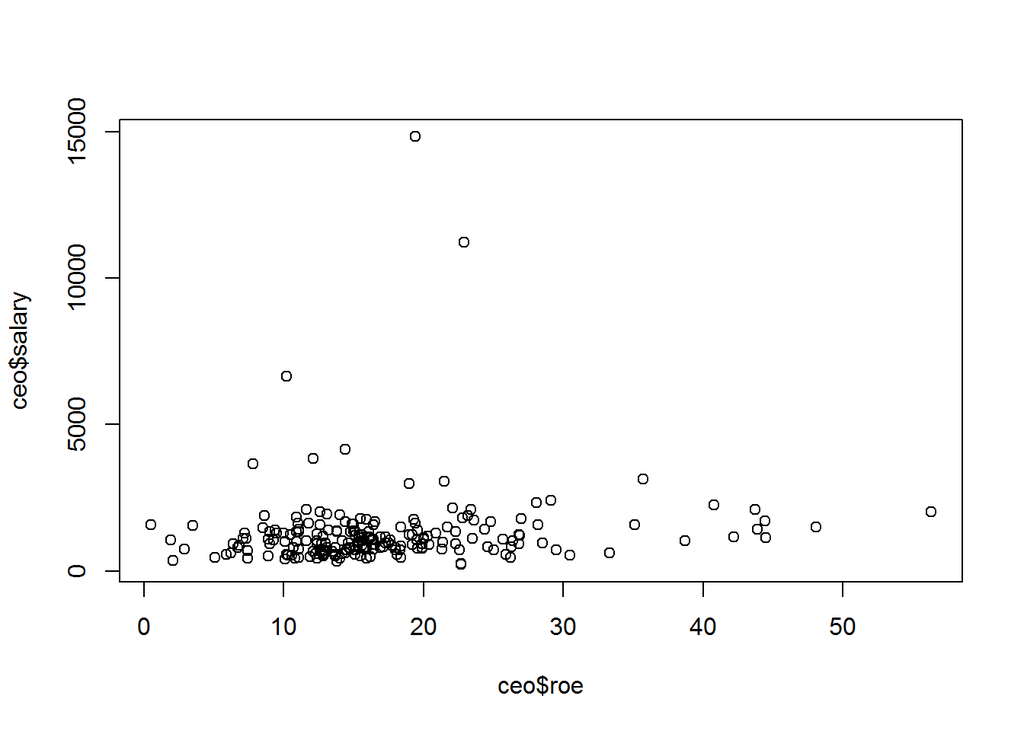

```r
plot(ceo$roe, y=ceo$salary)
```

Of course, the graph is not very pretty, but can be made nicer by tinkering with the `plot` options (there are many many options!)

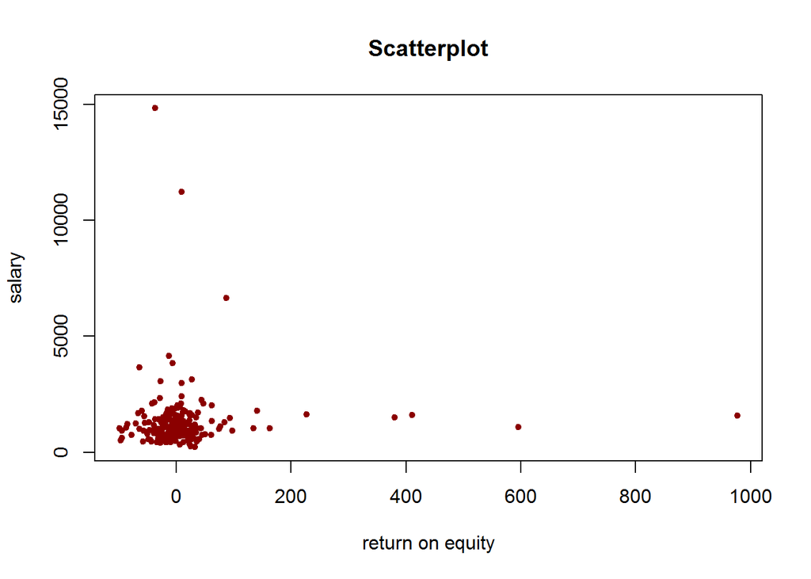

```r
plot(ceo$pcroe, y=ceo$salary, main = "Scatterplot", xlab = "return on equity", ylab = "salary", pch = 20, col = "darkred")
```

An histogram of `salary` can be obtained by using

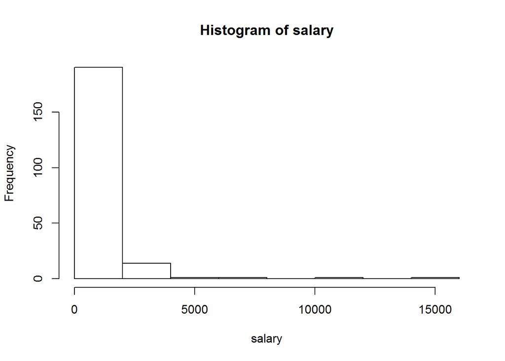

```r
with(ceo, hist(salary))
```

`hist` try to figure out the optimal number of breaks between histogram cells. This can be adjusted in several ways. You can pass the number of breaks `breaks = 15`, or the breaks `breaks = seq(0, 14821, 2000)`, or use an automatic algorithm by passing to `breaks` one of the three algorithms: `sturges`, `scott`, and `fd`.

```r
with(ceo, hist(salary, breaks = 15))
with(ceo, hist(salary, breaks = c(0, 200, 740, 1400, 2400, 5000, 14822)))
with(ceo, hist(salary, breaks = "scott"))
```

[output not shown]

The default histogram produces a count of the number of observations in each cell. To have instead the density of each bin the option `prob = TRUE` must be used.

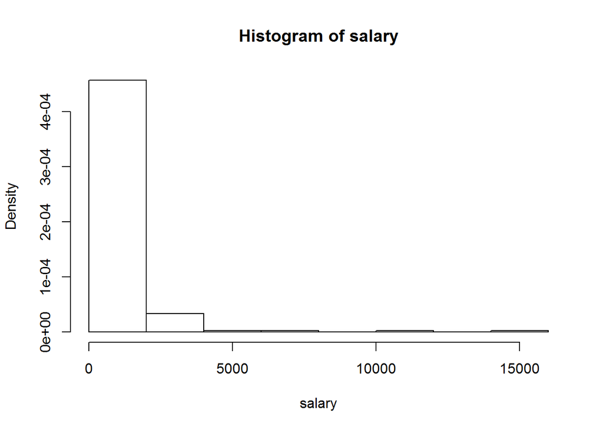

```r
h <- with(ceo, hist(salary, prob = TRUE))  ## Notice the assignment
```

The density values annoted on the y axis of the histogram are small because the are the number of observations in each beans divided the total number of observations divided again by the width of each bin. This means that the densities multiplied by the width of its own bin sum to 1. To see this, notice that in the above call we have assigned to `h` the output of `with(ceo, hist(salary, prob = TRUE))`. That is, `h` contains the information used by `R` to construct the histogram, as it can be seen by printing

```r
print(h)
```

```
## $breaks
## [1]     0  2000  4000  6000  8000 10000 12000 14000 16000
##
## $counts
## [1] 190  14   1   1   0   1   0   1
##
## $density
## [1] 4.567308e-04 3.365385e-05 2.403846e-06 2.403846e-06 0.000000e+00
## [6] 2.403846e-06 0.000000e+00 2.403846e-06
##
## $mids
## [1]  1000  3000  5000  7000  9000 11000 13000 15000
##
## $xname
## [1] "salary"
##
## $equidist
## [1] TRUE
##
## attr(,"class")
## [1] "histogram"
```

```r
h$density*2000
```

```
## [1] 0.913461538 0.067307692 0.004807692 0.004807692 0.000000000 0.004807692
## [7] 0.000000000 0.004807692
```

```r
sum(h$density*2000)
```

```
## [1] 1
```

### Box plot

The box plot describes the sample distribution. The box in the figure is the data corresponding to the 1th and 3rd quartile while the line inside the box is the 2nd quartile (i.e., the median). The whiskers extend out from the box such that the lowest datum is still within 1.5 * IQR of the lower quartile, and the highest datum is still within 1.5 * IQR of the upper quartile. Dots outside the whiskers can be interpreted as outlier.

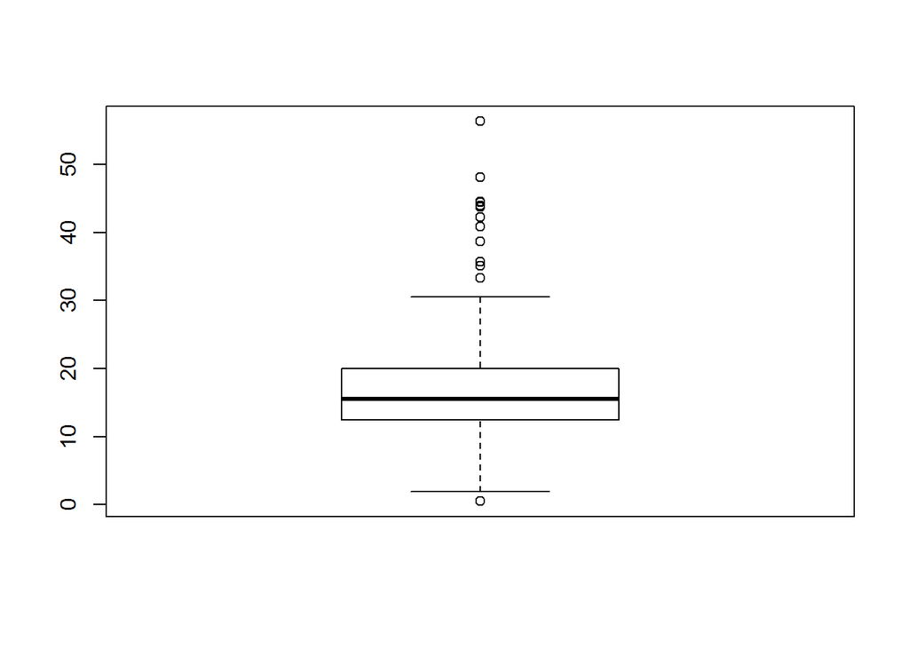

```r
boxplot(ceo$roe)
```

### Empirical Cumulative density function

Another way to represent the sample data is via the empirical cumulative density function (ecdf). The `R` function to calculate the ecdf is `ecdf`. This function returns an object of class `ecdf`, which is basically a function that can be evaluated at different values.

```r
x <- rnorm(100)
Psi <- ecdf(x)
Psi(-1.64)  ## should be around 0.05 for large n
```

```
## [1] 0.04
```

Think of evaluating the `ecdf` at each value in the support of the sample data e then plot $(\Psi(x), x)$ on a cartesian. This can be done easily by using the `plot` method for object of class `ecdf`. Here we plot the `ecdf` (in black) and the asymptotic version (i.e., the cdf of r.v. distributed as a $N(0,1)$).

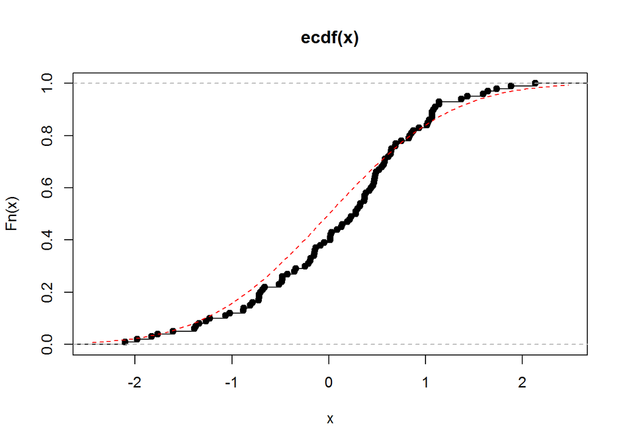

```r
plot(Psi)
curve(pnorm, col = "red", lty = 2, add = TRUE)
```

We now applied the `ecdf` to the `ceo` data, and specifically to the `roe` variable. We compare the `ecdf` of `roe` (in black) with the cdf of a Normal distribution with the sample mean and sample standard deviation of `ceo$roe`: $N(mean(ceo\$roe),sd(ceo\$roe))$ (in red).

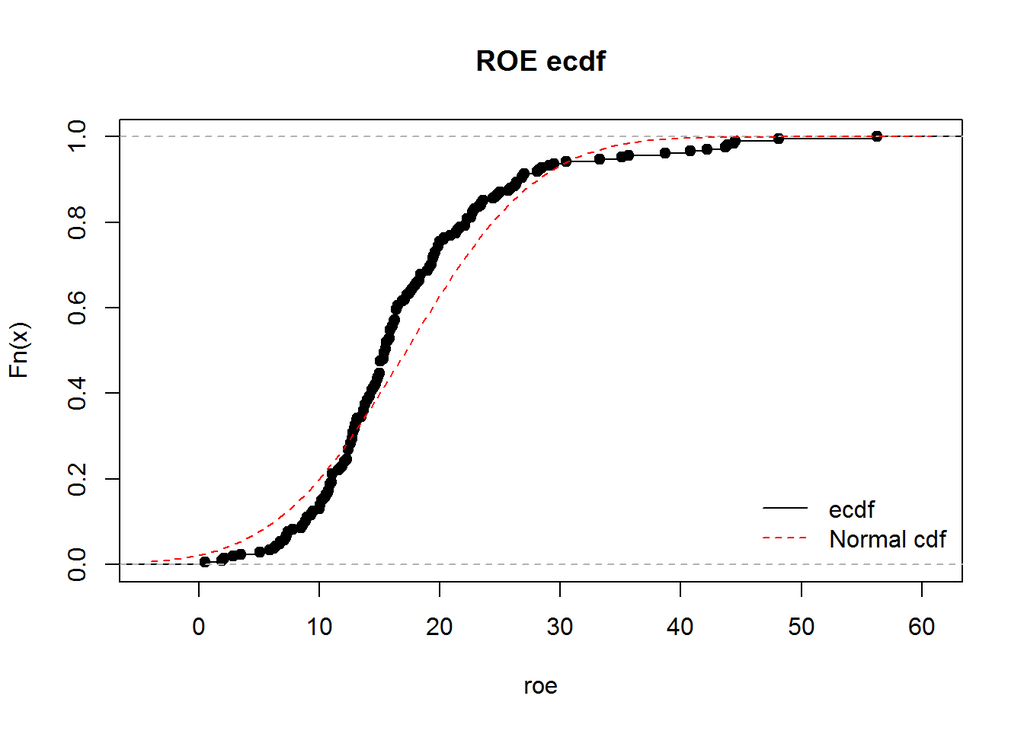

```r
plot(ecdf(ceo$roe), main = "ROE ecdf", xlab = "roe")
curve(pnorm(x, mean = mean(ceo$roe), sd = sd(ceo$roe)), col = "red", lty = 2, add = TRUE)
legend(x = 45, y = 0.2, legend = c("ecdf", "Normal cdf"), lty = c(1,2), col = c("black", "red"), bty = "n")
```

```r
roe_c <- with(ceo, roe[consprod==1])  ## subset ceo according to consprod
roe_n <- with(ceo, roe[consprod==0])
nc <- length(roe_c) ## length of samples
nn <- length(roe_n)
roebar_c <- mean(roe_c) ## sector specific ROE averages
roebar_n <- mean(roe_n)
Droe = roebar_c-roebar_n ## difference between averages
SE   = sqrt(var(roe_c)/nc + var(roe_n)/nn) ## calculate the SE of Droe
tstat = Droe/SE ## construct test statistic
print(tstat) ## print it on screen
```

```
## [1] 5.38229
```

```r
t.test(x, y = NULL,
            alternative = c("two.sided", "less", "greater"),
            mu = 0, paired = FALSE, var.equal = FALSE,
            conf.level = 0.95, ...)
```

```r
t.test(ceo[["roe"]], alternative = "less", mu = 17)
```

```
##
##  One Sample t-test
##
## data:  ceo[["roe"]]
## t = 0.3363, df = 207, p-value = 0.6315
## alternative hypothesis: true mean is less than 17
## 95 percent confidence interval:
##    -Inf 18.177
## sample estimates:
## mean of x
##  17.19905
```

More interestingly, this is the call to our testing problem.

```r
t.test(x = roe_c, y = roe_n, alternative = "greater", mu = 0)
```

```
##
##  Welch Two Sample t-test
##
## data:  roe_c and roe_n
## t = 5.3823, df = 79.919, p-value = 3.584e-07
## alternative hypothesis: true difference in means is greater than 0
## 95 percent confidence interval:
##  5.29703     Inf
## sample estimates:
## mean of x mean of y
##  22.65501  14.98717
```

We can calculate the p-value by ``hand’’ with following code.

```r
1-pt(tstat, df = 79.919)
```

```
## [1] 3.584259e-07
```

### Regression

We already saw how to draw a scatter plot. New we want to add a regression line to this graph (and we want also start making graphs look nicer).

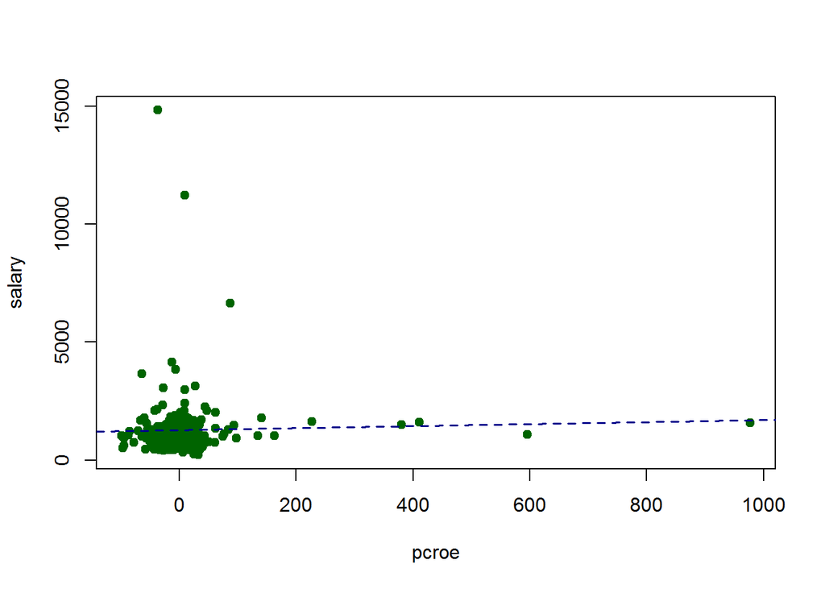

```r
with(ceo, plot(pcroe, salary, pch = 19, col = "darkgreen"))
abline(lm(salary~pcroe, data = ceo), col = "darkblue", lwd = 1.5, lty = 2)
```

The regression line is added by the call to `abline`, but what is interesting is that the argument to `abline` is another function call `lm(...)`. Indeed, `lm`, which stands for *linear model* is a powerful function with many options, but to quickly running a regression between two variables is relatively easy

```r
lm(salary~pcroe, data = ceo)
```

```
##
## Call:
## lm(formula = salary ~ pcroe, data = ceo)
##
## Coefficients:
## (Intercept)        pcroe
##   1277.7094       0.4163
```

Invoked directly (as was done above) the function returns the estimated coefficients and little else. We can also assign the results of the call to a variable.

```r
lm_1 <- lm(pcsalary~pcroe, data = ceo)
class(lm_1)
```

```
## [1] "lm"
```

`lm_1` is an object of class `lm` to which several methods are defined. For instance, we can extract the coefficient (`coef`), an estimate of the variance of the coefficients (`vcov`), and the residuals (`residuals`). The standard errors are the square root of the diagonal element sof the estimated variance.

```r
coef(lm_1)
```

```
## (Intercept)       pcroe
## 12.52815423  0.06980514
```

```r
vcov(lm_1)
```

```
##              (Intercept)         pcroe
## (Intercept)  5.002409598 -0.0054369433
## pcroe       -0.005436943  0.0005257724
```

```r
sqrt(diag(vcov(lm_1)))  ## standard errors
```

```
## (Intercept)       pcroe
##  2.23660672  0.02292973
```

```r
head(resid(lm_1))
```

```
##          1          2          3          4          5          6
##  21.607884  -2.390330 -19.734161  -5.318739  -7.597959  -2.116304
```

To get more information from the regression we can use the `summary` or `summary_rob` function in package ase. The difference between the two functions will be clear in a couple of classes.

```r
summary(lm(pcsalary~pcroe, data = ceo))
```

```
##
## Call:
## lm(formula = pcsalary ~ pcroe, data = ceo)
##
## Residuals:
##     Min      1Q  Median      3Q     Max
## -70.876 -13.748  -4.984   6.538 197.022
##
## Coefficients:
##             Estimate Std. Error t value Pr(>|t|)
## (Intercept) 12.52815    2.23661   5.601 6.75e-08 ***
## pcroe        0.06981    0.02293   3.044  0.00264 **
## ---
## Signif. codes:  0 '***' 0.001 '**' 0.01 '*' 0.05 '.' 0.1 ' ' 1
##
## Residual standard error: 32.08 on 206 degrees of freedom
## Multiple R-squared:  0.04305,    Adjusted R-squared:  0.03841
## F-statistic: 9.268 on 1 and 206 DF,  p-value: 0.002636
```

```r
summary_rob(lm(pcsalary~pcroe, data = ceo)) ## equivalent summary_rob(lm_1)
```

```
##
## Coefficients:
##             Estimate Std. Error z value Pr(>|z|)
## (Intercept) 12.52815    2.16986   5.774 7.75e-09
## pcroe        0.06981    0.04433   1.575    0.115
## ---
## Heteroskadasticity robust standard errors used
##
## Residual standard error: 32.08 on 206 degrees of freedom
## Multiple R-squared:  0.04305,    Adjusted R-squared:  0.03841
## F-statistic: 2.479 on 1 and Inf DF,  p-value: 0.1154
```